# Data 606 Homework 2

Anthony Pagan

September 10, 2018

## Week 2 Homework

2.6 Dice rolls. If you roll a pair of fair dice, what is the probability of

##### (a) getting a sum of 1?

###### $\color{red}{\text{There will be a 0 probabilty of getting a pair of dice to sum to 1 as the lowest sum would be 2}}$

##### (b) getting a sum of 5?

```r
({1/6}^2)*4
```

###### $\color{red}{\text{The sum of 5 would include the roll of 2/3, 3/2, 1/4 and 5/1. Each die has 1/6 chance, each rolls is 1/6*1/6 or 4/36 which equals 0.1111111}}$

##### (c) getting a sum of 12?

```r
({1/6}^2)
```

###### $\color{red}{\text{The sum of 12 would included the roll of 6/6. Each die has 1/6 chance, each rolls is 1/6*1/6 or 1/36 which equals 0.0277778}}$

2.8 Poverty and language. The American Community Survey is an ongoing survey that provides data every year to give communities the current information they need to plan investments and services. The 2010 American Community Survey estimates that 14.6% of Americans live below the poverty line, 20.7% speak a language other than English (foreign language) at home, and 4.2% fall into both categories.59

##### (a) Are living below the poverty line and speaking a foreign language at home disjoint?

###### $\color{red}{\text{These 2 datums are NOT disjoint, living below the poverty line and speaking a foreign language are not mutually exclusive, they can happen at the same time. }}$

##### (b) Draw a Venn diagram summarizing the variables and their associated probabilities.

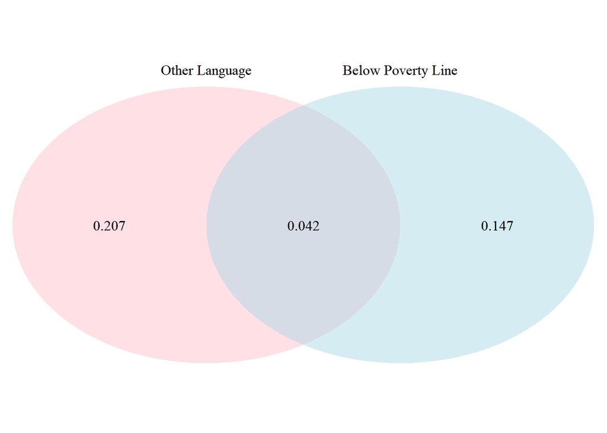

```
## (polygon[GRID.polygon.1], polygon[GRID.polygon.2], polygon[GRID.polygon.3], polygon[GRID.polygon.4], text[GRID.text.5], text[GRID.text.6], text[GRID.text.7], text[GRID.text.8], text[GRID.text.9])
```

```r
library(VennDiagram)
grid.newpage()
draw.pairwise.venn(.189, .249, .042, category = c("Below Poverty Line", "Other Language"), lty = rep("blank", 2), fill = c("light blue", "pink"), alpha = rep(0.5, 2), cat.pos = c(0,0), cat.dist = rep(0.025, 2), scaled = FALSE )
```

##### (c) What percent of Americans live below the poverty line and only speak English at home?

```r
.207*.146
```

##### (d) What percent of Americans live below the poverty line or speak a foreign language at home?

```r
.207+.146
```

###### $\color{red}{\text{The percentage of Americans below poverty level or only speak english would apply the addition rule. The result is 0.353 }}$

##### (e) What percent of Americans live above the poverty line and only speak English at home?

```r
(1-.207)*(1-.146)
```

##### (a) What is the probability that a randomly chosen male respondent or his partner has blue eyes?

```r
(78/204)+(78/204)
```

###### $\color{red}{\text{The probability would be the number of female with blue eyes/total male partners plus males with blue eyes/total female partners 0.7647059 }}$

##### (b) What is the probability that a randomly chosen male respondent with blue eyes has a partner with blue eyes?

```r
(78/204)*(78/204)
```

###### $\color{red}{\text{The probability would be the number of female with blue eyes/total male partners multiplied by males with blue eyes/total female partners 0.1461938 }}$

##### (c) What is the probability that a randomly chosen male respondent with brown eyes has a partner with blue eyes? What about the probability of a randomly chosen male respondent with green eyes having a partner with blue eyes?

```r
(19/204) and (11/204)
```

###### $\color{red}{\text{The probability would be the number of males with brown eyes and panters with blue eys/total partners which is 0.0931373 }}$

###### $\color{red}{\text{The probability would be the number of males with green eyes and panters with blue eys/total partners which is 0.0539216 }}$

###### (a) Find the probability of drawing a hardcover book ???rst then a paperback ???ction book second when drawing without replacement.

```r
(28/95)*(59/(95-1))
```

###### $\color{red}{\text{The probability would be the total hardcover/total books times total paperback fiction/books total minus one 0.1849944}}$

###### (b) Determine the probability of drawing a ???ction book ???rst and then a hardcover book second, when drawing without replacement.

```r
(72/95)*(28-1)/(95-1)
```

###### $\color{red}{\text{The probability would be the total fiction/total books times total paperback hardcover minus one/books total minus one 0.2176932}}$

###### (c) Calculate the probability of the scenario in part (b), except this time complete the calculations under the scenario where the ???rst book is placed back on the bookcase before randomly drawing the second book.

```r
(72/95)*(28/95)
```

###### $\color{red}{\text{The probability would be the total fiction/total books times total paperback hardcover/books total 0.2233795}}$

###### (d) The ???nal answers to parts (b) and (c) are very similar. Explain why this is the case.

###### $\color{red}{\text{The answers are similar because it is only a difference of 1 item. This is not a large enough a difference for a drastic change in probability. }}$

2.38 Baggage fees. An airline charges the following baggage fees: $25 for the ???rst bag and $35 for the second. Suppose 54% of passengers have no checked luggage, 34% have one piece of checked luggage and 12% have two pieces. We suppose a negligible portion of people check more than two bags.

###### (a) Build a probability model, compute the average revenue per passenger, and compute the corresponding standard deviation.

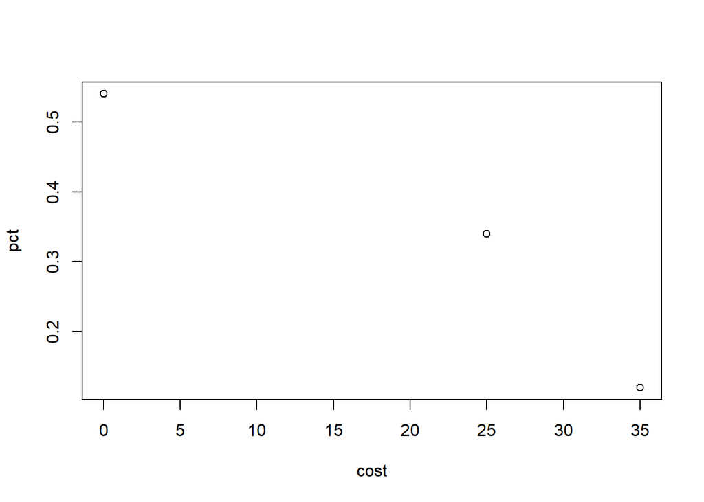

```r
bags <- c(0,1,2)
pct <-  c(.54,.34,.12)
cost <- c(0,25,35)
one <- pct[2]*cost[2]
two <- one + pct[3]*cost[3]
evalue <- one + two
stdv <-sd(cost*pct)
plot(cost, pct)
```

###### $\color{red}{\text{The Average revenue is 21.2 and the standard deviation is 4.250098}}$

###### (b) About how much revenue should the airline expect for a ???ight of 120 passengers? With what standard deviation? Note any assumptions you make and if you think they are justi???ed.

```r
ev <- 120*evalue
```

###### (a) Describe the distribution of total personal income.

###### $\color{red}{\text{This distribution of personal income will be slightly skewed to the right as ~20% of personal income is > 75k}}$

###### (b) What is the probability that a randomly chosen US resident makes less than $50,000 per year?

```r
b<- 2.2+4.7+15.8+18.3+21.2
```

###### $\color{red}{\text{The probability will be the total percentages below 50k which is 62.2%}}$

###### (c) What is the probability that a randomly chosen US resident makes less than$50,000 per year and is female? Note any assumptions you make.

```r
c <- b*.41
```

###### $\color{red}{\text{The probability would take answer to question b (62.2%) times the percentage of female population of 41%. Result is 25.502%}}$

###### (d) The same data source indicates that 71.8% of females make less than $50,000 per year. Use this value to determine whether or not the assumption you made in part (c) is valid.

###### $\color{red}{\text{Based on this data my assumptions were incorrect. My assumptions that income would meet a normal distribution regardless of male or female. }}$

###### $\color{red}{\text{The numbers show salary are not normally distributed and females are paid less then the numbers show.}}$